# DL: segmentación de un mando de videoconsola con UNET

Entrenamos una red UNET (`code/DL/UNET`) para segmentar un mando de videoconsola en imágenes de cámara: la salida es una máscara que indica qué píxeles pertenecen al mando.

## Flujo seguido

Se sigue el pipeline de `code/DL/UNET/README.txt`:

1. `masker.py` — marcar a mano la región del mando sobre cada foto para generar las máscaras.
2. `prepare.py` — recortes 128×128 (positivos centrados en el mando + negativos por el resto, con espejado) → `mando.npz`.
3. `train.py` — entrena 20 épocas y guarda `model.torch`. Se repite varias veces partiendo del anterior.
4. `check.py` — comprobación visual (entrada / máscara real / predicha).
5. `rununet.py` — aplica el modelo en directo a la cámara.

## Datos

8 fotos del mando (`mando/mando1.png` ... `mando/mando8.png`), con distintos fondos, ángulos y distancias, y sus máscaras dibujadas a mano con `masker.py` (`mando/mask_mando*.png`).

`./prepare.py --examples=mando` genera 640 recortes 128x128 (`mando.npz`): para cada foto, varios recortes centrados en la región del mando y otros repartidos por toda la imagen como ejemplos negativos, más sus versiones espejadas.

## Entrenamiento

| tras (épocas) | loss |
| --- | --- |
| 20 | 11528 |
| 40 | 7869 |
| 60 | 6758 |
| 80 | 4638 |
| 100 | 3181 |
| 120 | 1961 |
| 140 | 1081 |
| 160 | 945 |
| 180 | 927 |
| 200 | 533 |
| 220 | 862 |
| 240 | 846 |
| 260 | 280 |
| 280 | 241 |

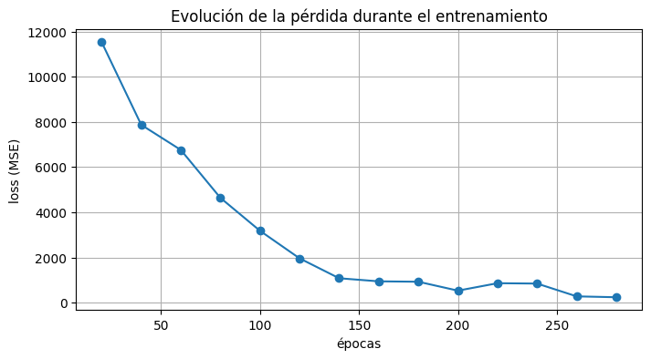

```python
import matplotlib.pyplot as plt

epochs = [20,40,60,80,100,120,140,160,180,200,220,240,260,280]
loss   = [11528,7869,6758,4638,3181,1961,1081,945,927,533,862,846,280,241]

plt.figure(figsize=(8,4))
plt.plot(epochs, loss, '-o')
plt.xlabel('épocas')
plt.ylabel('loss (MSE)')
plt.title('Evolución de la pérdida durante el entrenamiento')
plt.grid(True)
plt.show()
```

## Resultados

### `check.py`: recortes 128x128 (entrada / máscara real / máscara predicha)

Tras 80 épocas el modelo ya distingue aproximadamente la región del mando, pero los bordes son difusos:

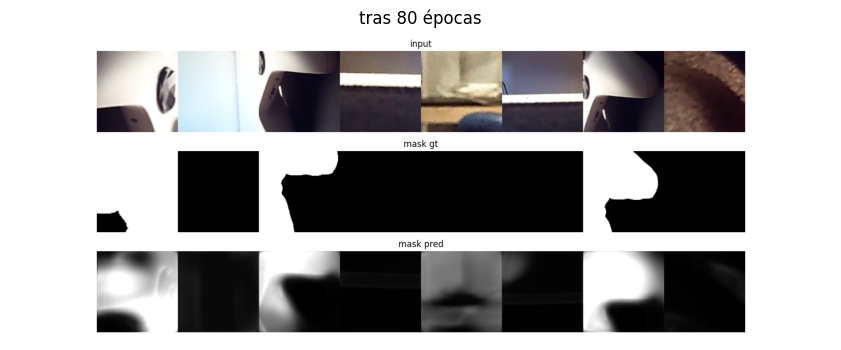

```python
import matplotlib.pyplot as plt
import cv2 as cv

def fig(w,h):
    plt.figure(figsize=(w,h))

def readrgb(file):
    return cv.cvtColor(cv.imread(file), cv.COLOR_BGR2RGB)

fig(14,4)
plt.imshow(readrgb('ejemplos/check_inicial.png'))
plt.axis('off')
plt.title('tras 80 épocas')
plt.show()
```

Tras 280 épocas la máscara predicha es prácticamente indistinguible de la real:

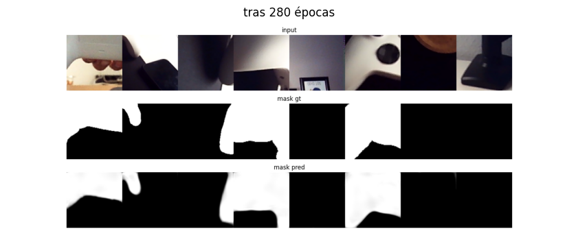

```python
fig(14,4)
plt.imshow(readrgb('ejemplos/check_final.png'))
plt.axis('off')
plt.title('tras 280 épocas')
plt.show()
```

### Imágenes completas

[figure not shown]

```python
fig(16,3)
plt.imshow(readrgb('ejemplos/full_frames.png'))
plt.axis('off')
plt.show()
```

## Uso en directo

[output not shown]

Muestra la cámara en directo con solo la región del mando visible (el resto en negro), junto con el tiempo de inferencia en ms.

## Notas

- Con solo 8 fotos y 280 épocas el modelo ya generaliza razonablemente bien a las imágenes completas; con más fotos (más fondos, iluminaciones, mandos distintos) la segmentación en directo sería más robusta.